# Library Tips for Econ Thesis Students

Ryan Clement

Fall 2019

## Who is your librarian?

I am! My name is Ryan Clement, and I am the Data Services Librarian at Middlebury. I’m the librarian for the Economics, Geography, Sociology/Anthropology, and Philosophy departments. I also help people from across the college in working with data, whether it is finding, acquiring, managing, interpreting, analyzing, or visualizing it. I am also the Government Documents librarian and can help with finding and acquiring materials from the US Government.

## How can you find your librarian?

You can make an appointment with me by going to http://go.middlebury.edu/ryan/ and clicking ‘Schedule appointment.’ That tool syncs with my calendar, so you don’t have to worry about my availability. All of my other contact info is also on that page.

## Where should I look for economic literature?

The top places I would recommend to start looking for economics literature are:

- EconLit ([go/econlit/](http://go.middlebury.edu/econlit))
  - EconLit is from the American Economic Association, and contains *only* economic literature, including scholarly articles, book chapters, and some working papers.
  - EconLit has ‘full text’ searching available for most articles it indexes. To do this, you must select ‘TX All Text’ from the drop-down next to your search box. Try your search without it first, but if you’re not finding enough results, try searching full text.

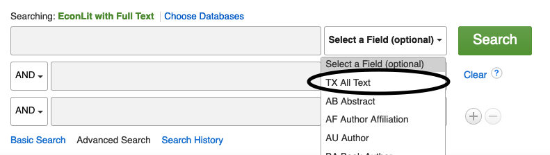

Searching full text in EconLit

- EconPapers ([go/econpapers/](http://go.middlebury.edu/econpapers))
  - EconPapers provides access to more working papers than EconLit, so go there if you need working papers.
  - Working papers are valuable for researching cutting-edge and current topics. They have not been peer-reviewed in the same way papers published in scholarly journals have, but you can still look for marks of quality, such as the working paper series that published the paper (e.g. NBER working papers, University of Oxford working papers, etc.).
  - **CAUTION**: don’t use working papers that are older than a couple of years. If it was a high-quality piece of research, you should find it in a scholarly journal. If not, it wasn’t high-quality and you should be wary of using it.
- Scopus ([go/scopus/](http://go.middlebury.edu/scopus))
  - Scopus is particularly effective for doing ‘cited reference searching’ - this is where you find all of the articles that cited an article you know. You can use Scopus this way by searching for an article that you know is a quality article on your topic, and then looking on the far-right column of the results for the ‘Cited by’ column. Click on that, and you’ll see papers that cited your original paper.
- Google Scholar (scholar.google.com)
  - Google Scholar is another option for cited reference searching, particularly when you can’t find anything on Scopus.
  - **CAUTION**: Google Scholar indexes many things, so you should be careful to make sure that what you’re finding through it is of high quality.
- The Econ Research Guide ([go/econguide/](http://go.middlebury.edu/econguide))
  - There are a number of other resources in this guide, and my contact info again!

## How do I search these things effectively?

Library catalogs and databases want to balance *precision* with *recall*. They want to get you either the *exact* thing your searching for, or *everything* on the topic your searching for. Google just wants to get you a *good enough* answer. Because of this, you can’t search these two things in the same way. While you can type a question into Google, or use misspelled words, or not worry about synonyms, you can’t do these things with library tools.

You need to:

1. Break your research question/topic into ‘concepts’
2. Brainstorm keywords for each of these concepts (think about synonyms, and how economists talk about these concepts)
3. Try out a search, maybe find some papers, read them
4. Adjust your concepts and your keywords lists
5. Try another search

As you can see, searching is an iterative process. You **will** make changes and adjustments and search the literature a number of times. So it is important to **keep track of what you’re doing**. Keep it in a Word/Google doc, or a text file, or even in a handwritten notebook. **Just keep track of it!**

Library tools use boolean logic to combine keywords. You can use AND, OR, and NOT (typing them in caps helps the tool know that you’re using them as a boolean operator, not a word).

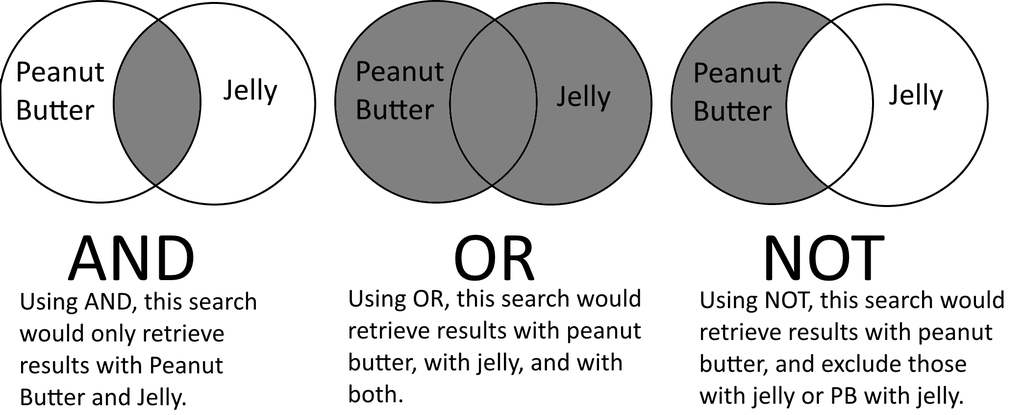

## How do I deal with all of the stuff I find?

In the library, we recommend and support [Zotero](https://zotero.org) for citation and research management. You can find information on how to get started and use Zotero in our Research Guide at http://go.middlebury.edu/zotero. You can also contact me for help with using Zotero.